# Project Python Foundations: FoodHub Data Analysis

### Question 12: Perform bivariate/multivariate analysis to explore relationships between the important variables in the dataset. (7 marks)

```python
correlation = df.corr()
correlation
```

|  | order_id | customer_id | cost_of_the_order | food_preparation_time | delivery_time |
| --- | --- | --- | --- | --- | --- |
| order_id | 1.000000 | -0.013960 | 0.021171 | -0.007026 | 0.009690 |
| customer_id | -0.013960 | 1.000000 | -0.001322 | -0.030330 | -0.009885 |
| cost_of_the_order | 0.021171 | -0.001322 | 1.000000 | 0.041527 | -0.029949 |
| food_preparation_time | -0.007026 | -0.030330 | 0.041527 | 1.000000 | 0.011094 |
| delivery_time | 0.009690 | -0.009885 | -0.029949 | 0.011094 | 1.000000 |

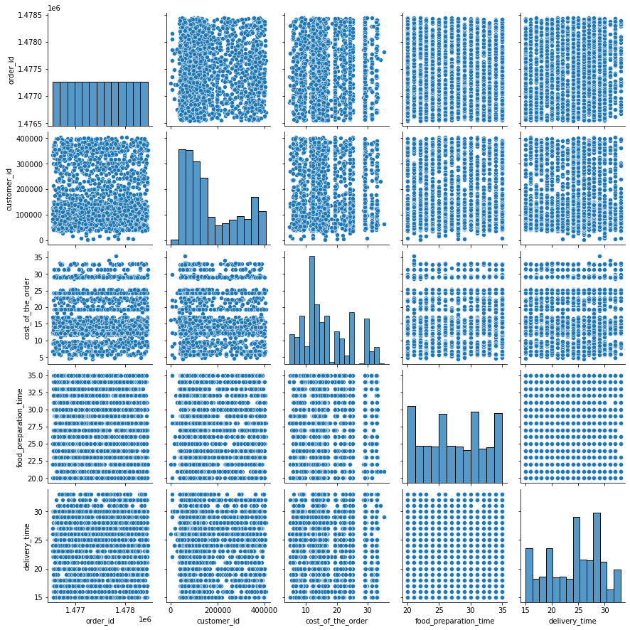

```python
sns.pairplot(df)
plt.savefig("output.jpg", bbox_inches='tight')
```

[output not shown]

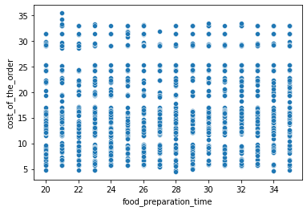

```python
sns.scatterplot(df['food_preparation_time'], df['cost_of_the_order'])
```

Observation: The cost of the order appears not to be dependent on the food prepartion time, with orders with a food preparation time of over 34 still having different order costs.

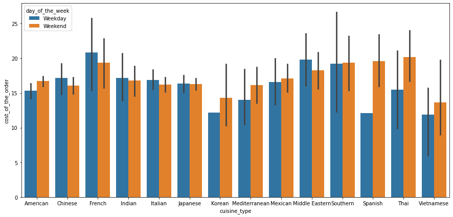

```python
#There a is relationship between cuisine type and cost of delivery during the day of the week(relationship between numeric and categorical variable)
plt.figure(figsize =(15,7))
sns.barplot(x = 'cuisine_type', data = df, y = 'cost_of_the_order', hue = 'day_of_the_week')
plt.savefig("output.jpg", bbox_inches='tight')
```

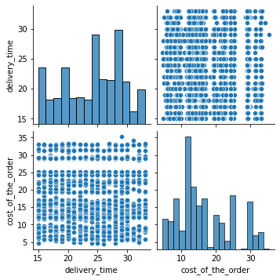

```python
#Observations on Cuisine_type
sns.pairplot(df[['delivery_time','cost_of_the_order']])
plt.show()
plt.savefig("output.jpg", bbox_inches='tight')
```

Observation: In terms of cost of order and delivery time the orders appear to be delivered timely irrespective of the cost of the order

[output not shown]

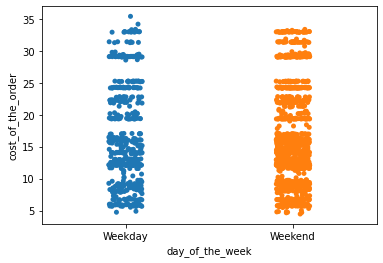

```python
#Observation on which day of the week has more orders in terms of cost_of_the_order
sns.stripplot(df['day_of_the_week'], df['cost_of_the_order'])
plt.show()
plt.savefig("output.jpg", bbox_inches='tight')
```

Observation: The weekend appears to have more orders than the weekday given the density of the data.